# R bootcamp, Module 1: Basics

August 2014, UC Berkeley

Chris Paciorek

# R as a calculator

```r
2 + 2  # add numbers
```

```
## [1] 4
```

```r
2 * pi  # multiply by a constant
```

```
## [1] 6.283
```

```r
7 + runif(1)  # add a random number
```

```
## [1] 7.008
```

```r
3^4  # powers
```

```
## [1] 81
```

```r
sqrt(4^4)  # functions
```

```
## [1] 16
```

```r
log(10)
```

```
## [1] 2.303
```

```r
log(100, base = 10)
```

```
## [1] 2
```

```r
23%/%2
```

```
## [1] 11
```

```r
23%%2
```

```
## [1] 1
```

```r
# scientific notation
5e+09 * 1000
```

```
## [1] 5e+12
```

```r
5e+09 * 1000
```

```
## [1] 5e+12
```

Think of a mathematical operation you need - can you guess how to do it in R?

# Assigning values to R objects

A key action in R is to store values in the form of R objects, and to examine the value of R objects.

```r
val <- 3
val
```

```
## [1] 3
```

```r
print(val)
```

```
## [1] 3
```

```r
Val <- 7  # case-sensitive!
print(c(val, Val))
```

```
## [1] 3 7
```

We can work with (and store) sequences and repetitions

```r
mySeq <- 1:6
mySeq
```

```
## [1] 1 2 3 4 5 6
```

```r
myOtherSeq <- seq(1.1, 11.1, by = 2)
myOtherSeq
```

```
## [1]  1.1  3.1  5.1  7.1  9.1 11.1
```

```r
length(myOtherSeq)
```

```
## [1] 6
```

```r
fours <- rep(4, 6)
fours
```

```
## [1] 4 4 4 4 4 4
```

```r
# This is a comment: here is an example of non-numeric data
depts <- c("espm", "pmb", "stats")
depts
```

```
## [1] "espm"  "pmb"   "stats"
```

If we don't assign the output of a command to an object, we haven't saved it for later use.

R gives us a lot of flexibility (within certain rules) for assigning to (parts of) objects from (parts of) other objects.

# How to be [lazy](http://dilbert.com/strips/comic/2005-05-29/)

If you're starting to type something you've typed before, or the long name of an R object or function, STOP! You likely don't need to type all of that.

- Tab completion
- Command history
  - up/down arrows
  - Ctrl-{up arrow} or Command-{up arrow}
- RStudio: select a line or block for execution
- Put your code in a file and use `source()`. For example: `source('myRcodeFile.R')`

**Question**: Are there other tricks that anyone knows of?

# Vectors in R

The most basic form of an R object is a vector. In fact, individual (scalar) values are vectors of length one.

We can concatenate values into a vector with `c()`.

```r
# numeric vector
nums <- c(1.1, 3, -5.7)
devs <- rnorm(5)
devs
```

```
## [1] -0.9314  0.8248  1.5676  2.6781  1.4619
```

```r
# integer vector
ints <- c(1L, 5L, -3L)  # force storage as integer not decimal number
# 'L' is for 'long integer' (historical)

idevs <- sample(ints, 100, replace = TRUE)

# character vector
chars <- c("hi", "hallo", "mother's", "father's", "She said, 'hi'", "He said, \"hi\"")
chars
```

```
## [1] "hi"              "hallo"           "mother's"        "father's"
## [5] "She said, 'hi'"  "He said, \"hi\""
```

```r
cat(chars, sep = "\n")
```

```
## hi
## hallo
## mother's
## father's
## She said, 'hi'
## He said, "hi"
```

```r
# logical vector
bools <- c(TRUE, FALSE, TRUE)
bools
```

```
## [1]  TRUE FALSE  TRUE
```

# Working with indices and subsets

```r
vals <- seq(2, 12, by = 2)
vals
```

```
## [1]  2  4  6  8 10 12
```

```r
vals[3]
```

```
## [1] 6
```

```r
vals[3:5]
```

```
## [1]  6  8 10
```

```r
vals[c(1, 3, 6)]
```

```
## [1]  2  6 12
```

```r
vals[-c(1, 3, 6)]
```

```
## [1]  4  8 10
```

```r
vals[c(rep(TRUE, 3), rep(FALSE, 2), TRUE)]
```

```
## [1]  2  4  6 12
```

We can substitute values into vectors

```r
vals[4] <- -35
vals[1:2] <- 0

vals <- rnorm(100)
# How does R process these next subset operations?
vals[vals < 0] <- 0
vals[1:8]
```

```
## [1] 0.01345 0.00000 1.40390 0.00000 0.00000 0.00000 0.18311 1.50344
```

```r
set.seed(0)  # make random number generation repeatable
vals <- rnorm(100)
extremes <- vals[vals > 3]
extremes
```

```
## numeric(0)
```

```r
# what happened?
```

# Vectorized calculations and comparisons

At the core of R is the idea of doing calculations on entire vectors.

```r
vec1 <- sample(1:5, 10, replace = TRUE)
vec2 <- sample(1:5, 10, replace = TRUE)
vec1
```

```
##  [1] 4 2 2 3 2 1 3 3 1 2
```

```r
vec2
```

```
##  [1] 4 5 1 4 5 5 2 4 5 5
```

```r
vec1 + vec2
```

```
##  [1] 8 7 3 7 7 6 5 7 6 7
```

```r
vec1^vec2
```

```
##  [1] 256  32   2  81  32   1   9  81   1  32
```

```r
vec1 >= vec2
```

```
##  [1]  TRUE FALSE  TRUE FALSE FALSE FALSE  TRUE FALSE FALSE FALSE
```

```r
vec1 <= 3
```

```
##  [1] FALSE  TRUE  TRUE  TRUE  TRUE  TRUE  TRUE  TRUE  TRUE  TRUE
```

```r
vec1 == vec2
```

```
##  [1]  TRUE FALSE FALSE FALSE FALSE FALSE FALSE FALSE FALSE FALSE
```

```r
vec1 != vec2
```

```
##  [1] FALSE  TRUE  TRUE  TRUE  TRUE  TRUE  TRUE  TRUE  TRUE  TRUE
```

```r
# careful:
vec1 = vec2
identical(vec1, vec2)
```

```
## [1] TRUE
```

An important related concept is that of recycling

```r
vec3 <- sample(1:5, 5, replace = TRUE)
vec4 <- sample(1:5, 3, replace = TRUE)
vec1
```

```
##  [1] 4 5 1 4 5 5 2 4 5 5
```

```r
vec3
```

```
## [1] 2 2 1 2 3
```

```r
vec4
```

```
## [1] 5 3 2
```

```r
vec1 + vec3
```

```
##  [1] 6 7 2 6 8 7 4 5 7 8
```

```r
vec1 + vec4
```

```
##  [1]  9  8  3  9  8  7  7  7  7 10
```

**Question**: Tell me what's going on. What choices were made by the R developers?

# R is a functional language

- Operations are carried out with functions. Functions take objects as inputs and return objects as outputs.
- An analysis can be considered a pipeline of function calls, with output from a function used later in a subsequent operation as input to another function.
- Functions themselves are objects:

```r
sum
```

```
## function (..., na.rm = FALSE)  .Primitive("sum")
```

```r
class(sum)
```

```
## [1] "function"
```

- We can embed function calls:

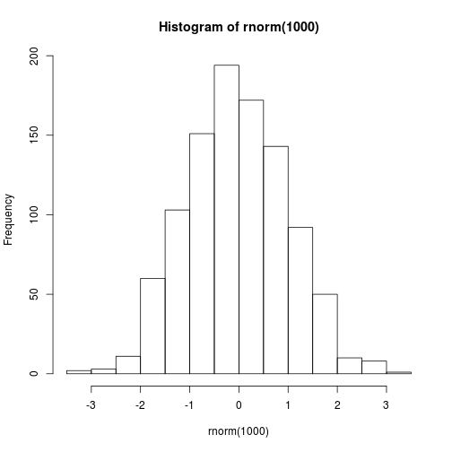

```r
hist(rnorm(1000))
```

# Getting help about a function

To get information about a function you know exists, use `help` or `?`, e.g., `?lm`. For information on a general topic, use `apropos` or `??`

```r
help(lm)
`?`(lm)

`?`(log)

# ??'regr' # take out the '#' to demo live - there's an issue with Markdown
# processing...
```

# Basic kinds of R objects

Vectors are not the only kinds of R objects.

### Vectors

Vectors of various types (numeric (i.e., decimal/floating point/double), integer, boolean, character), all items must be of the same type

### Matrices

Matrices of various types, all items must be of the same type

```r
mat <- matrix(rnorm(9), nrow = 3)
t(mat) %*% mat
```

```
##        [,1]   [,2]   [,3]
## [1,]  1.621  1.650 -1.223
## [2,]  1.650  1.954 -1.507
## [3,] -1.223 -1.507  4.047
```

```r
dim(mat)
```

```
## [1] 3 3
```

### Data frames

Collections of columns of potentially different types

```r
library(foreign)
vote <- read.dta("../data/2004_labeled_processed_race.dta")
head(vote)
```

```
##   state pres04    sex  race  age9 partyid income relign8 age60 age65
## 1     2      1 female white 25-29    <NA>   <NA>    <NA> 18-29 25-29
## 2     2      2   male white 18-24    <NA>   <NA>    <NA> 18-29 18-24
## 3     2      1 female black 30-39    <NA>   <NA>    <NA> 30-44 30-39
## 4     2      1 female black 30-39    <NA>   <NA>    <NA> 30-44 30-39
## 5     2      1 female white 40-44    <NA>   <NA>    <NA> 30-44 40-49
## 6     2      1 female white 30-39    <NA>   <NA>    <NA> 30-44 30-39
##   geocode sizeplac brnagain attend year region y
## 1       3    rural     <NA>   <NA> 2004      4 0
## 2       3    rural     <NA>   <NA> 2004      4 1
## 3       3    rural     <NA>   <NA> 2004      4 0
## 4       3    rural     <NA>   <NA> 2004      4 0
## 5       3    rural     <NA>   <NA> 2004      4 0
## 6       3    rural     <NA>   <NA> 2004      4 0
```

```r
dim(vote)
```

```
## [1] 76205    17
```

```r
nrow(vote)
```

```
## [1] 76205
```

```r
names(vote)
```

```
##  [1] "state"    "pres04"   "sex"      "race"     "age9"     "partyid"
##  [7] "income"   "relign8"  "age60"    "age65"    "geocode"  "sizeplac"
## [13] "brnagain" "attend"   "year"     "region"   "y"
```

```r
class(vote)
```

```
## [1] "data.frame"
```

```r
is.matrix(vote)
```

```
## [1] FALSE
```

```r
class(vote$pres04)
```

```
## [1] "integer"
```

```r
class(vote$sex)
```

```
## [1] "factor"
```

```r
class(vote$age9)
```

```
## [1] "factor"
```

### Lists

Collections of disparate or complicated objects

```r
myList <- list(stuff = 3, mat = matrix(1:4, nrow = 2), moreStuff = c("china",
    "japan"), list(5, "bear"))
myList
```

```
## $stuff
## [1] 3
##
## $mat
##      [,1] [,2]
## [1,]    1    3
## [2,]    2    4
##
## $moreStuff
## [1] "china" "japan"
##
## [[4]]
## [[4]][[1]]
## [1] 5
##
## [[4]][[2]]
## [1] "bear"
```

```r
myList[[1]]  # result is not (usually) a list (unless you have nested lists)
```

```
## [1] 3
```

```r
identical(myList[[1]], myList$stuff)
```

```
## [1] TRUE
```

```r
myList$moreStuff[2]
```

```
## [1] "japan"
```

```r
myList[[4]][[2]]
```

```
## [1] "bear"
```

```r
myList[1:3]  # subset of a list is a list
```

```
## $stuff
## [1] 3
##
## $mat
##      [,1] [,2]
## [1,]    1    3
## [2,]    2    4
##
## $moreStuff
## [1] "china" "japan"
```

```r
myList$newOne <- "more weird stuff"
names(myList)
```

```
## [1] "stuff"     "mat"       "moreStuff" ""          "newOne"
```

Lists can be used as vectors of complicated objects. E.g., suppose you have a linear regression for each value of a stratifying variable. You could have a list of regression fits. Each regression fit will itself be a list, so you'll have a list of lists.

# Other classes of objects

R has several approaches to object-oriented programming. These are widely used, albeit a bit klunky.

The most basic is 'S3' objects. These objects are generally built upon lists.

```r
y <- rnorm(10)
x <- rnorm(10)
mod <- lm(y ~ x)
class(mod)
```

```
## [1] "lm"
```

```r
is.list(mod)
```

```
## [1] TRUE
```

```r
names(mod)
```

```
##  [1] "coefficients"  "residuals"     "effects"       "rank"
##  [5] "fitted.values" "assign"        "qr"            "df.residual"
##  [9] "xlevels"       "call"          "terms"         "model"
```

```r
mod$coefficients
```

```
## (Intercept)           x
##     -0.3874      0.1842
```

```r
mod[["coefficients"]]
```

```
## (Intercept)           x
##     -0.3874      0.1842
```

```r
mod[[1]]
```

```
## (Intercept)           x
##     -0.3874      0.1842
```

The magic of OOP here is that methods (i.e., functions) can be tailored to work specifically with specific kinds of objects.

```r
summary(y)
```

```
##    Min. 1st Qu.  Median    Mean 3rd Qu.    Max.
##  -1.880  -0.799  -0.647  -0.290   0.521   1.330
```

```r
summary(mod)
```

```
##
## Call:
## lm(formula = y ~ x)
##
## Residuals:
##    Min     1Q Median     3Q    Max
## -1.909 -0.372 -0.159  0.603  1.460
##
## Coefficients:
##             Estimate Std. Error t value Pr(>|t|)
## (Intercept)   -0.387      0.340   -1.14     0.29
## x              0.184      0.250    0.74     0.48
##
## Residual standard error: 0.989 on 8 degrees of freedom
## Multiple R-squared:  0.0635, Adjusted R-squared:  -0.0536
## F-statistic: 0.542 on 1 and 8 DF,  p-value: 0.483
```

**Question**: What do you think R is doing behind the scenes?

Consider `summary.lm`.

# Converting between different types of objects

You can use the `as()` family of functions.

```r
ints <- 1:10
as.character(ints)
```

```
##  [1] "1"  "2"  "3"  "4"  "5"  "6"  "7"  "8"  "9"  "10"
```

```r
as.numeric(c("3.7", "4.8"))
```

```
## [1] 3.7 4.8
```

Be careful: R tries to be helpful and convert between types/classes when it thinks it's a good idea. Sometimes it is overly optimistic.

```r
indices <- c(1.7, 2.3)
ints[indices]
```

```
## [1] 1 2
```

```r
ints[0.999999999]
```

```
## integer(0)
```

# Managing your objects

R has a number of functions for getting metadata about your objects. Some of this is built in to RStudio.

```r
vec1 <- 1:4
vec2 <- c(1, 2, 3, 4)

length(vec1)
```

```
## [1] 4
```

```r
str(vec1)
```

```
##  int [1:4] 1 2 3 4
```

```r
class(vec1)
```

```
## [1] "integer"
```

```r
typeof(vec1)
```

```
## [1] "integer"
```

```r
class(vec2)
```

```
## [1] "numeric"
```

```r
typeof(vec2)
```

```
## [1] "double"
```

```r
is.vector(vec1)
```

```
## [1] TRUE
```

```r
is.list(vec1)
```

```
## [1] FALSE
```

```r
is.list(myList)
```

```
## [1] TRUE
```

```r
is.vector(myList)
```

```
## [1] TRUE
```

```r
is.data.frame(vote)
```

```
## [1] TRUE
```

```r
is.list(vote)
```

```
## [1] TRUE
```

**Question**: What have you learned? Does it make sense?

# A bit on plotting

R has several different plotting systems:

- *base* graphics
- *lattice* graphics
- *ggplot2* (an add-on package)

We'll see a little bit of *base* graphics here and then *lattice* and *ggplot2* tomorrow in Module 8.

```r
earnings <- read.dta("../data/heights.dta")
names(earnings)
```

```
## [1] "earn"    "height1" "height2" "sex"     "race"    "hisp"    "ed"
## [8] "yearbn"  "height"
```

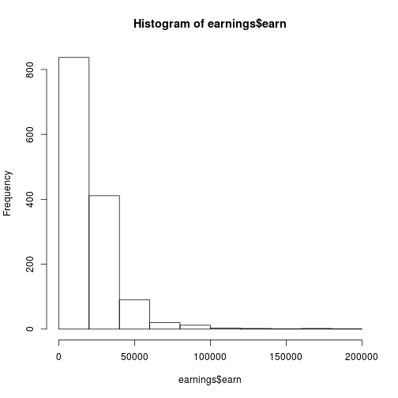

```r
hist(earnings$earn)
```

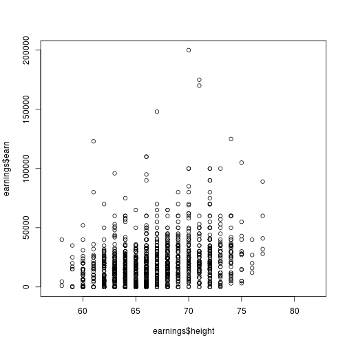

```r
plot(earnings$earn ~ earnings$height)
```

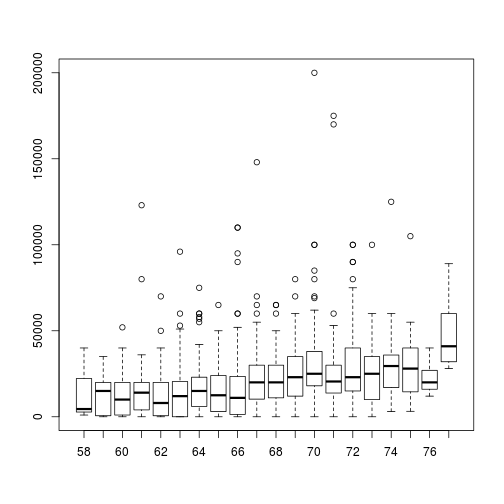

```r
boxplot(earnings$earn ~ earnings$height)
```

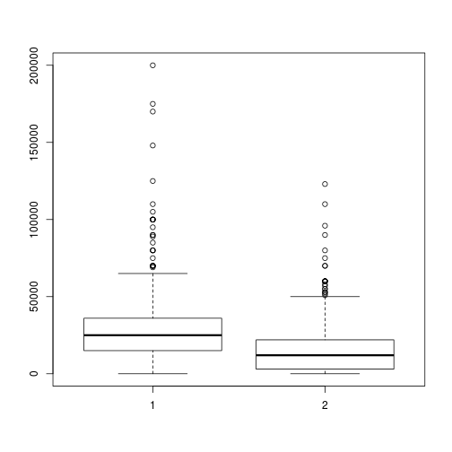

```r
boxplot(earnings$earn ~ earnings$sex)
```

# Graphics options

Check out `help(par)` for various [graphics settings](http://xkcd.com/833/); these are set via `par()` or within the specific graphics command (some can be set in either place), e.g.,

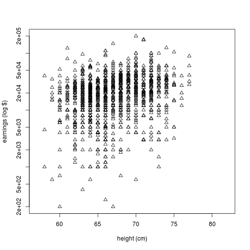

```r
par(pch = 2)
plot(earnings$earn ~ earnings$height, xlab = "height (cm)", ylab = "earnings (log $)",
    log = "y")
```

# Breakout